# hw1_part2

Выполнил студент БВТ2002 Митрофанов Алексей

### О задании

Задание состоит из двух разделов, посвященных работе с табличными данными с помощью библиотеки pandas и визуализации с помощью matplotlib. В каждом разделе вам предлагается выполнить несколько заданий.

Задание направлено на освоение jupyter notebook (будет использоваться в дальнейших заданиях), библиотекам pandas и matplotlib.

## 0. Введение

Сейчас мы находимся в jupyter-ноутбуке (или ipython-ноутбуке). Это удобная среда для написания кода, проведения экспериментов, изучения данных, построения визуализаций и других нужд, не связанных с написаем production-кода.

Ноутбук состоит из ячеек, каждая из которых может быть либо ячейкой с кодом, либо ячейкой с текстом размеченным и неразмеченным. Текст поддерживает markdown-разметку и формулы в Latex.

Для работы с содержимым ячейки используется *режим редактирования* (*Edit mode*, включается нажатием клавиши **Enter** после выбора ячейки), а для навигации между ячейками искользуется *командный режим* (*Command mode*, включается нажатием клавиши **Esc**). Тип ячейки можно задать в командном режиме либо с помощью горячих клавиш (**y** to code, **m** to markdown, **r** to edit raw text), либо в меню *Cell -> Cell type*.

После заполнения ячейки нужно нажать *Shift + Enter*, эта команда обработает содержимое ячейки: проинтерпретирует код или сверстает размеченный текст.

```python
# ячейка с кодом, при выполнении которой появится output
2 + 2
```

```
4
```

А это ___ячейка с текстом___.

Ячейка с неразмеченыным текстом.

Попробуйте создать свои ячейки, написать какой-нибудь код и текст какой-нибудь формулой.

```python
# your code
```

[Здесь](https://athena.brynmawr.edu/jupyter/hub/dblank/public/Jupyter%20Notebook%20Users%20Manual.ipynb) находится небольшая заметка о используемом языке разметки Markdown. Он позволяет:

0. Составлять упорядоченные списки

# Делать

## заголовки

### разного уровня

3. Выделять *текст* при **необходимости**
4. Добавлять [ссылки](http://imgs.xkcd.com/comics/the_universal_label.png)
- Составлять неупорядоченные списки

Делать вставки с помощью LaTex:

$ \left\{ \begin{array}{ll} x = 16 \sin^3 (t) \\ y = 13 \cos (t) - 5 \cos (2t) - 2 \cos (3t) - \cos (4t) \\ t \in [0, 2 \pi] \end{array} \right.$

## 1. Табличные данные и Pandas

Pandas — удобная библиотека для работы с табличными данными в Python, если данных не слишком много и они помещаются в оперативную память вашего компьютера. Несмотря на неэффективность реализации и некоторые проблемы, библиотека стала стандартом в анализе данных. С этой библиотекой мы сейчас и познакомимся.

Основной объект в pandas это DataFrame, представляющий собой таблицу с именованными колонками различных типов, индексом (может быть многоуровневым). DataFrame можно создавать, считывая таблицу из файла или задавая вручную из других объектов.

В этой части потребуется выполнить несколько небольших заданий. Можно пойти двумя путями: сначала изучить материалы, а потом приступить к заданиям, или же разбираться "по ходу". Выбирайте сами.

Материалы:

1. [Pandas за 10 минут из официального руководства](http://pandas.pydata.org/pandas-docs/stable/10min.html)
2. [Документация](http://pandas.pydata.org/pandas-docs/stable/index.html) (стоит обращаться, если не понятно, как вызывать конкретный метод)
3. [Примеры использования функционала](http://nbviewer.jupyter.org/github/justmarkham/pandas-videos/blob/master/pandas.ipynb)

Многие из заданий можно выполнить несколькими способами. Не существуют единственно верного, но попробуйте максимально задействовать арсенал pandas и ориентируйтесь на простоту и понятность вашего кода. Мы не будем подсказывать, что нужно использовать для решения конкретной задачи, попробуйте находить необходимый функционал сами (название метода чаще всего очевидно). В помощь вам документация, поиск и stackoverflow.

```python
%matplotlib inline
import pandas as pd
```

Данные можно скачать [отсюда](https://www.dropbox.com/s/5qq94wzmbw4e54r/data.csv?dl=0).

#### 1. Откройте файл с таблицей (не забудьте про её формат). Выведите последние 10 строк.

Посмотрите на данные и скажите, что они из себя представляют, сколько в таблице строк, какие столбцы?

```python
data = pd.read_csv('./data.csv')

data.head(5) # первые 5 строк
```

|  | order_id | quantity | item_name | choice_description | item_price |
| --- | --- | --- | --- | --- | --- |
| 0 | 1 | 1 | Chips and Fresh Tomato Salsa | NaN | $2.39 |
| 1 | 1 | 1 | Izze | [Clementine] | $3.39 |
| 2 | 1 | 1 | Nantucket Nectar | [Apple] | $3.39 |
| 3 | 1 | 1 | Chips and Tomatillo-Green Chili Salsa | NaN | $2.39 |
| 4 | 2 | 2 | Chicken Bowl | [Tomatillo-Red Chili Salsa (Hot), [Black Beans... | $16.98 |

```python
data.tail(10) # последние 10 строк
```

|  | order_id | quantity | item_name | choice_description | item_price |
| --- | --- | --- | --- | --- | --- |
| 4612 | 1831 | 1 | Carnitas Bowl | [Fresh Tomato Salsa, [Fajita Vegetables, Rice,... | $9.25 |
| 4613 | 1831 | 1 | Chips | NaN | $2.15 |
| 4614 | 1831 | 1 | Bottled Water | NaN | $1.50 |
| 4615 | 1832 | 1 | Chicken Soft Tacos | [Fresh Tomato Salsa, [Rice, Cheese, Sour Cream]] | $8.75 |
| 4616 | 1832 | 1 | Chips and Guacamole | NaN | $4.45 |
| 4617 | 1833 | 1 | Steak Burrito | [Fresh Tomato Salsa, [Rice, Black Beans, Sour ... | $11.75 |
| 4618 | 1833 | 1 | Steak Burrito | [Fresh Tomato Salsa, [Rice, Sour Cream, Cheese... | $11.75 |
| 4619 | 1834 | 1 | Chicken Salad Bowl | [Fresh Tomato Salsa, [Fajita Vegetables, Pinto... | $11.25 |
| 4620 | 1834 | 1 | Chicken Salad Bowl | [Fresh Tomato Salsa, [Fajita Vegetables, Lettu... | $8.75 |
| 4621 | 1834 | 1 | Chicken Salad Bowl | [Fresh Tomato Salsa, [Fajita Vegetables, Pinto... | $8.75 |

```python
# вывод размерности датафрейма
data.shape
```

```
(4622, 5)
```

- Данные представляют собой список заказов с перечнем заказанных позиций, таблица имеет следующие столбцы: номер заказа, количество, название позиции, описание выбора клиента, цена
- Таблица содержит 4622 строки, 5 столбцов

#### 2. [0.25 баллов] Ответьте на вопросы:

1. Сколько заказов попало в выборку? **1834**
2. Сколько уникальных категорий товара было куплено? (item_name) **50**

```python
data['order_id'].unique().shape
```

```
(1834,)
```

```python
data['item_name'].unique().shape
```

```
(50,)
```

#### 3. [0.25 баллов] Есть ли в данных пропуски? В каких колонках?

```python
data.isna().any()
```

```
order_id              False
quantity              False
item_name             False
choice_description     True
item_price            False
dtype: bool
```

- В данных есть пропуски, они встречаются только в столбце `choice_description`

Заполните пропуски пустой строкой для строковых колонок и нулём для числовых.

```python
data.dtypes
```

```
order_id               int64
quantity               int64
item_name             object
choice_description    object
item_price            object
dtype: object
```

```python
# проверка значения и типа во 2 строке столбца `choice_description`
print(data['choice_description'][2])
print(type(data['choice_description'][2]))
```

```
[Apple]
<class 'str'>
```

- Столбец `choice_description` имеет тип object, однако в уже заполненых ячейках лежат данные типа str, поэтому **заполним пустые ячейки пустыми строками**

```python
data = data.fillna('')
```

#### 4. [0.5 баллов] Посмотрите внимательнее на колонку с ценой товара. Какого она типа? Создайте новую колонку так, чтобы в ней цена была числом.

Для этого попробуйте применить функцию-преобразование к каждой строке вашей таблицы (для этого есть соответствующая функция).

```python
# проверка значения и типа ячейки во 2 строке столбца `item_price`
print(data['item_price'][2])
print(type(data['item_price'][2]))
```

```
$3.39
<class 'str'>
```

- Цена представлена в датафрейме типом str (строкой)
- Приведем значения цены к числовому типу с фиксированной запятой

```python
def str_to_decimal(x: str):
    from decimal import Decimal
    # убираем пробелы и знак '$', преобразуем в Decimal
    return Decimal(x.strip('$').strip())
```

```python
data['converted_price'] = data['item_price'].apply(str_to_decimal)
```

```python
# проверка значения и типа ячейки во 2 строке столбца `converted_price`
print(type(data['converted_price'][2]))
```

```
<class 'decimal.Decimal'>
```

Какая средняя/минимальная/максимальная цена у товара?

```python
# создаем новую колонку для хранения цены за штуку. значения в ней получаются путем деления цены на количество товара
data['price_for_one'] = data['converted_price'] / data['quantity']
```

```python
data['price_for_one'].mean()
```

```
7.084424491562094
```

```python
data['price_for_one'].min()
```

```
Decimal('1.09')
```

```python
data['price_for_one'].max()
```

```
Decimal('11.89')
```

- Средняя цена: **7.08**
- Минимальная цена: **1.09**
- Максимальная цена: **11.89**

Удалите старую колонку с ценой.

```python
data.pop('item_price')
```

```
0        $2.39
1        $3.39
2        $3.39
3        $2.39
4       $16.98
         ...
4617    $11.75
4618    $11.75
4619    $11.25
4620     $8.75
4621     $8.75
Name: item_price, Length: 4622, dtype: object
```

#### 5. [0.25 баллов] Какие 5 товаров были самыми дешёвыми и самыми дорогими? (по choice_description)

Для этого будет удобно избавиться от дубликатов и отсортировать товары. Не забудьте про количество товара.

Самые **дешевые** товары:

```python
data[['choice_description', 'converted_price','price_for_one', 'quantity']].drop_duplicates().sort_values(by = 'price_for_one', ascending=True).head(5)
```

|  | choice_description | converted_price | price_for_one | quantity |
| --- | --- | --- | --- | --- |
| 28 | [Dr. Pepper] | 1.09 | 1.09 | 1 |
| 228 | [Mountain Dew] | 1.09 | 1.09 | 1 |
| 34 |  | 1.09 | 1.09 | 1 |
| 352 | [Coca Cola] | 2.18 | 1.09 | 2 |
| 200 | [Diet Coke] | 1.09 | 1.09 | 1 |

Самые **дорогие** товары:

```python
data[['choice_description', 'converted_price','price_for_one', 'quantity']].drop_duplicates().sort_values(by = 'price_for_one', ascending=False).head(5)
```

|  | choice_description | converted_price | price_for_one | quantity |
| --- | --- | --- | --- | --- |
| 4239 | [Tomatillo Green Chili Salsa, [Black Beans, Ch... | 11.89 | 11.89 | 1 |
| 2442 | [Tomatillo Green Chili Salsa, [Rice, Fajita Ve... | 11.89 | 11.89 | 1 |
| 3350 | [Fresh Tomato Salsa, [Cheese, Guacamole, Lettu... | 11.89 | 11.89 | 1 |
| 1505 | [Fresh Tomato Salsa, [Rice, Pinto Beans, Chees... | 11.89 | 11.89 | 1 |
| 1132 | [Fresh Tomato Salsa, [Rice, Black Beans, Chees... | 11.89 | 11.89 | 1 |

#### 6. [0.5 баллов] Сколько раз клиенты покупали больше 1 Chicken Bowl (item_name)?

```python
# фильтруем датафрейм по наличию Chicken Bowl в `item_name`
is_chicken_bowl = data['item_name'] == 'Chicken Bowl'
filtered_data = data[['order_id', 'item_name','quantity']][is_chicken_bowl]

# группируем по номеру заказа, суммируем количество
#
# (Иногда Chicken Bowl заказывают с разным choice_description, поэтому в таблице
# есть несколько вхождений Chicken Bowl с одним и тем же номером заказа, и иногда
# с разным количеством.
# Поэтому будем считать не количество вхождений Chicken Bowl или максимальное
# quantity, а будем считать сумму quantity для каждого номера заказа)

quantity_sum = filtered_data.groupby('order_id')['quantity'].sum()

more_than_one = quantity_sum > 1
quantity_sum[more_than_one].shape
```

```
(114,)
```

Получилось 114 вхождений

- Ответ: 114 раз клиенты покупали больше одного Chicken Bowl

#### 7. [0.5 баллов] Какой средний чек у заказа? Сколько в среднем товаров покупают?

Если необходимо провести вычисления в терминах заказов, то будет удобно сгруппировать строки по заказам и посчитать необходимые статистики.

```python
# сгрупируем вхождения по номеру заказа, просуммируем цены позиций, найдем средний чек
data.groupby('order_id')['converted_price'].sum().mean()
```

```
18.811428571428575
```

- Средний чек у заказа: **18.81**

```python
# замечание: можно посчитать сколько УНИКАЛЬНЫХ товаров за заказ покупают,
# а можно посчитать общее число количества товаров за заказ

### подсчет количества УНИКАЛЬНЫХ товаров за заказ (не учитывая choice_description) ###
# отбрасываем дублирующиеся позиции, группируем по заказу, подсчитываем кол-во
# вхождений, рассчитываем среднее
data.drop_duplicates(subset=['order_id', 'item_name']).groupby('order_id').count().mean()
```

```
quantity              2.34024
item_name             2.34024
choice_description    2.34024
converted_price       2.34024
price_for_one         2.34024
dtype: float64
```

```python
### подсчет общего числа купленных товаров за заказ ###
# группируем, суммируем количества, рассчитываем среднее
data.groupby('order_id')['quantity'].sum().mean()
```

```
2.711014176663032
```

- Среднее количество *уникальных* товаров за заказ: **2.34**
- Среднее количество *всех* товаров за заказ: **2.71**

#### 8. [0.25 баллов] Сколько заказов содержали ровно 1 товар?

```python
item_count = data.groupby('order_id')['quantity'].sum()
exactly_one = item_count == 1
item_count[exactly_one].shape
```

```
(56,)
```

- 56 заказов содержали ровно 1 товар

#### 9. [0.25 баллов] Какая самая популярная категория товара?

```python
# your code
data.groupby('item_name')['quantity'].sum().sort_values(ascending=False).head(5)
```

```
item_name
Chicken Bowl           761
Chicken Burrito        591
Chips and Guacamole    506
Steak Burrito          386
Canned Soft Drink      351
Name: quantity, dtype: int64
```

- **Chicken Bowl** -- самая популярная категория товаров

#### 13. [0.75 баллов] Создайте новый DateFrame из матрицы, созданной ниже. Назовите колонки index, column1, column2 и сделайте первую колонку индексом.

```python
import numpy as np
df = np.random.rand(10, 3)
df

df = pd.DataFrame(data = df, columns=['index', 'col1', 'col2'])
df = df.set_index('index')
df
```

| index | col1 | col2 |
| --- | --- | --- |
| 0.037190 | 0.328657 | 0.834094 |
| 0.723127 | 0.646748 | 0.369869 |
| 0.290702 | 0.196661 | 0.140444 |
| 0.593988 | 0.482959 | 0.242440 |
| 0.362012 | 0.809926 | 0.338055 |
| 0.956317 | 0.868687 | 0.967691 |
| 0.051421 | 0.253248 | 0.643760 |
| 0.342241 | 0.194292 | 0.986688 |
| 0.589690 | 0.202079 | 0.344513 |
| 0.672903 | 0.296759 | 0.318087 |

Сохраните DataFrame на диск в формате csv без индексов и названий столбцов.

```python
df.to_csv('./rand_matrix.csv', header=False, index=False)
```

```python
with open('./rand_matrix.csv') as f:
    print(f.read())
```

```
0.3286569285870836,0.834094407872179
0.6467483410962079,0.36986921435058073
0.1966614268587057,0.1404437584142001
0.4829590140140002,0.24243992610995757
0.8099256199042364,0.3380547196124839
0.8686868318645262,0.9676908069604296
0.25324822915749057,0.6437604184679
0.19429181570816667,0.9866884279765327
0.20207850973720676,0.34451276725978963
0.29675925426765637,0.3180869379377259
```

## 2. Визуализации и matplotlib

При работе с данными часто неудобно делать какие-то выводы, если смотреть на таблицу и числа в частности, поэтому важно уметь визуализировать данные. В этом разделе мы этим и займёмся.

У matplotlib, конечно, же есть [документация](https://matplotlib.org/users/index.html) с большим количеством [примеров](https://matplotlib.org/examples/), но для начала достаточно знать про несколько основных типов графиков:

- plot — обычный поточечный график, которым можно изображать кривые или отдельные точки;
- hist — гистограмма, показывающая распределение некоторое величины;
- scatter — график, показывающий взаимосвязь двух величин;
- bar — столбцовый график, показывающий взаимосвязь количественной величины от категориальной.

В этом задании вы попробуете построить каждый из них. Не менее важно усвоить базовые принципы визуализаций:

- на графиках должны быть подписаны оси;
- у визуализации должно быть название;
- если изображено несколько графиков, то необходима поясняющая легенда;
- все линии на графиках должны быть чётко видны (нет похожих цветов или цветов, сливающихся с фоном);
- если отображена величина, имеющая очевидный диапазон значений (например, проценты могут быть от 0 до 100), то желательно масштабировать ось на весь диапазон значений (исключением является случай, когда вам необходимо показать малое отличие, которое незаметно в таких масштабах).

```python
%matplotlib inline
import matplotlib.pyplot as plt
import matplotlib
```

На самом деле мы уже импортировали matplotlib внутри %pylab inline в начале задания.

Работать мы будем с той же выборкой покупкок. Добавим новую колонку с датой покупки.

```python
import datetime
import random

start = datetime.datetime(2018, 1, 1)
end = datetime.datetime(2018, 1, 31)
delta_seconds = int((end - start).total_seconds())



dates = pd.DataFrame(index=data.order_id.unique())
dates['date'] = [
    (start + datetime.timedelta(seconds=random.randint(0, delta_seconds))).strftime('%Y-%m-%d')
    for _ in range(data.order_id.nunique())]

# если DataFrame с покупками из прошлого заказа называется не df, замените на ваше название ниже
data['date'] = data.order_id.map(dates['date'])
```

#### 1. [1 балл] Постройте гистограмму распределения сумм покупок и гистограмму средних цен отдельных видов продуктов item_name.

Изображайте на двух соседних графиках. Для этого может быть полезен subplot.

```python
import seaborn as sns
sns.set()
```

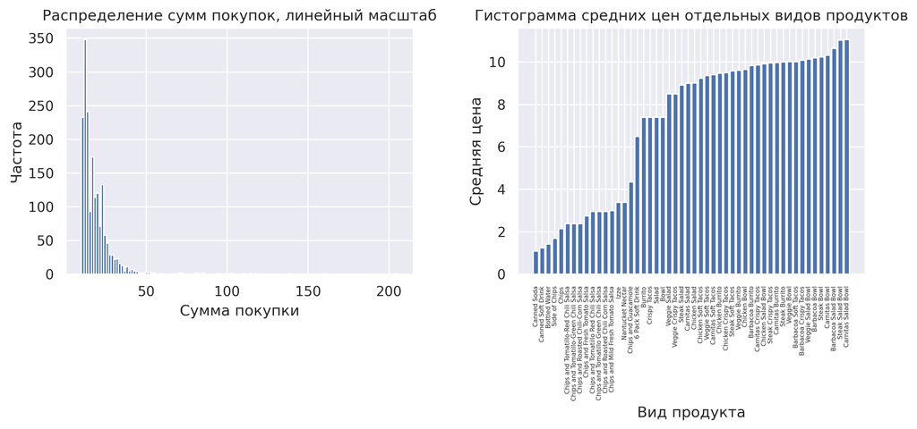

```python
# суммарные стоимости заказов
sums = data.groupby('order_id')['converted_price'].sum()

# создаем фигуру с тремя визуализациями, расположенными вертикально
fig, (ax1, ax2) = plt.subplots(1, 2)

# настройка линейного масштаба оси y
ax1.set_yscale('linear')
# sums.hist(ax=ax1, bins='auto')
ax1.hist(sums.values, bins='auto')

ax1.set_title('Распределение сумм покупок, линейный масштаб')
ax1.set_ylabel('Частота')
ax1.set_xlabel('Сумма покупки')


# средние цены отдельных видов продуктов
mean_prices = data.groupby('item_name')['price_for_one'].mean().sort_values(ascending=True)
labels = mean_prices.index
values = mean_prices.values

ax2.bar(labels, values)

# настройка подписей по оси x
ax2.set_xticks(labels= ax2.get_xticklabels(), ticks= ax2.get_xticks(), rotation = 90)
# установка размера шрифта
plt.xticks(fontsize = 5)
ax2.set_title('Гистограмма средних цен отдельных видов продуктов')
ax2.set_xlabel('Вид продукта')
ax2.set_ylabel('Средняя цена')

fig.set_dpi(300)
fig.set_size_inches(10, 5)
fig.tight_layout()
fig.subplots_adjust(wspace=0.3)
plt.show()
```

#### 2. [1 балл] Постройте график зависимости суммы покупок от дней.

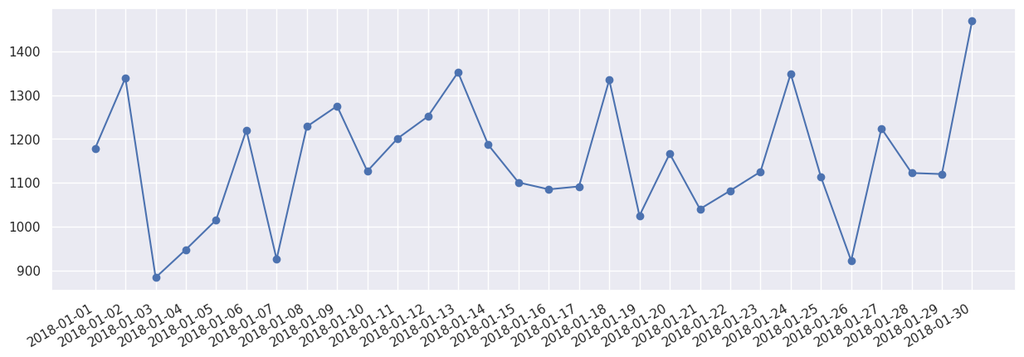

```python
date_sums = data.groupby('date')['converted_price'].sum()
dates = date_sums.index
sums = date_sums.values

plt.figure(figsize=(15,5))
plt.plot_date(x = dates, y = sums, xdate=True, linestyle='solid')
plt.gcf().autofmt_xdate()

pass
```

#### 3. [1 балл] Постройте график зависимости денег за товар от купленного количества (scatter plot).

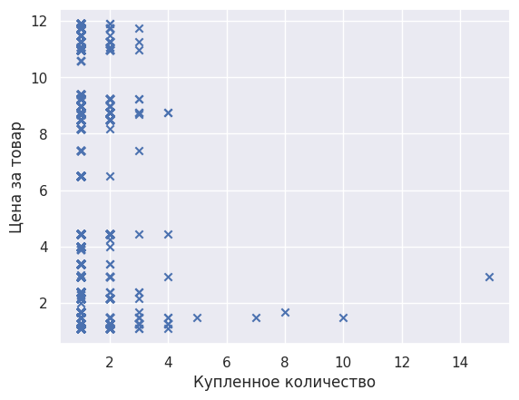

```python
# your code

prices = data['price_for_one']
quantity = data['quantity']

fig, ax = plt.subplots()

ax.scatter(x= quantity, y=prices, marker='x')
ax.set_ylabel('Цена за товар')
ax.set_xlabel('Купленное количество')
```

Сохраните график в формате pdf (так он останется векторизованным).

```python
fig.savefig('scatter.pdf', format='pdf')
```

Кстати, существует надстройка над matplotlib под названием [seaborn](https://jakevdp.github.io/PythonDataScienceHandbook/04.14-visualization-with-seaborn.html). Иногда удобнее и красивее делать визуализации через неё.